# HA adopters vs. nonadopters

[back to main page |](https://github.com/huiwen-goy/C2-multidomain) [Data quality |](https://huiwen-goy.github.io/C2-multidomain/C2-1Quality.html) [Demographics |](https://huiwen-goy.github.io/C2-multidomain/C2-2Demographic.html) [Physical health |](https://huiwen-goy.github.io/C2-multidomain/C2-3Physical.html) [Hearing |](https://huiwen-goy.github.io/C2-multidomain/C2-4Hearing.html) [Cognition |](https://huiwen-goy.github.io/C2-multidomain/C2-5Cognition.html) [Mobility and balance |](https://huiwen-goy.github.io/C2-multidomain/C2-6Mobility.html) [Quality of life |](https://huiwen-goy.github.io/C2-multidomain/C2-7QoL.html) [Mental health |](https://huiwen-goy.github.io/C2-multidomain/C2-8Mental.html) [Social participation and support |](https://huiwen-goy.github.io/C2-multidomain/C2-9Social.html) [Views on hearing loss |](https://huiwen-goy.github.io/C2-multidomain/C2-10Views.html)

# Three groups

Adopter = anybody who acquired hearing aids in Study 1 or Study 2  
NonAdopter = one or both ears with ≥35 dB HL at 2kHz, but did not acquire hearing aids at any point  
GoodAudio = no hearing aid acquisition, and not a candidate by the above criterion

*(In graphs: Miss = 79 participants without audiograms)*

# General characteristics

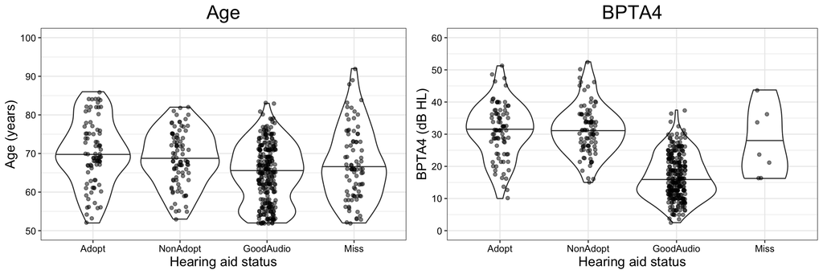

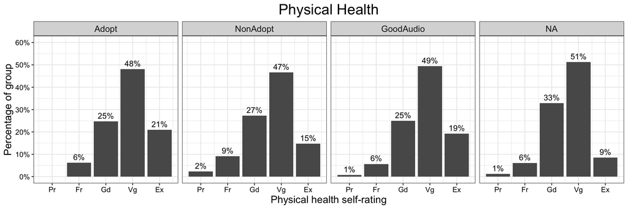

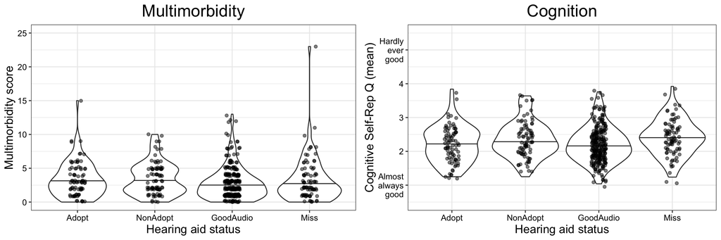

# Self-perceived hearing

back to top

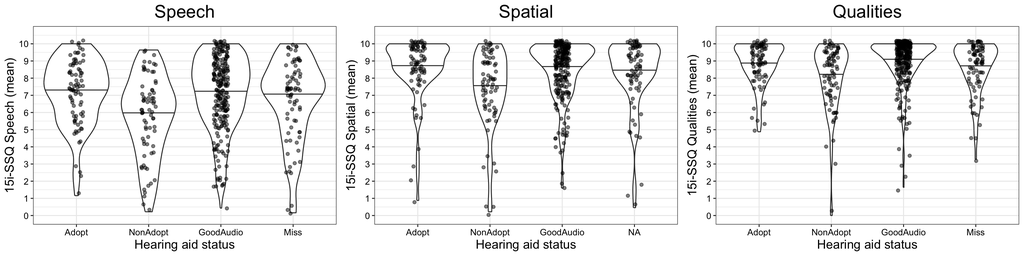

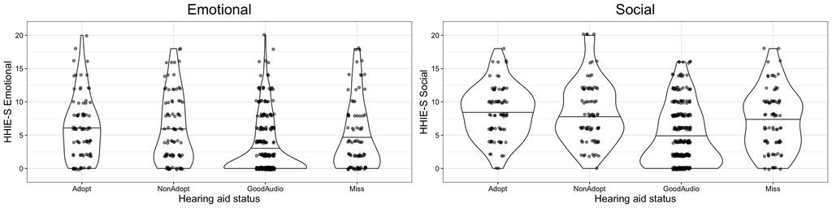

# Social and environmental factors

back to top

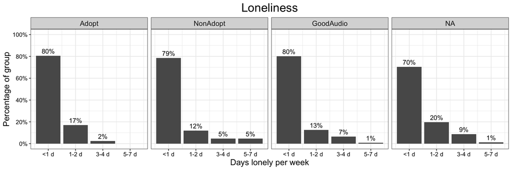

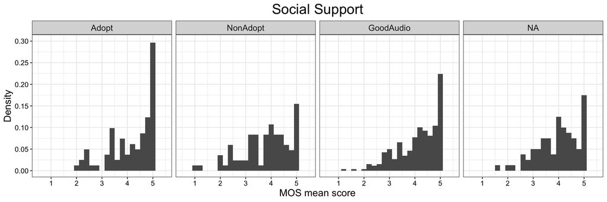

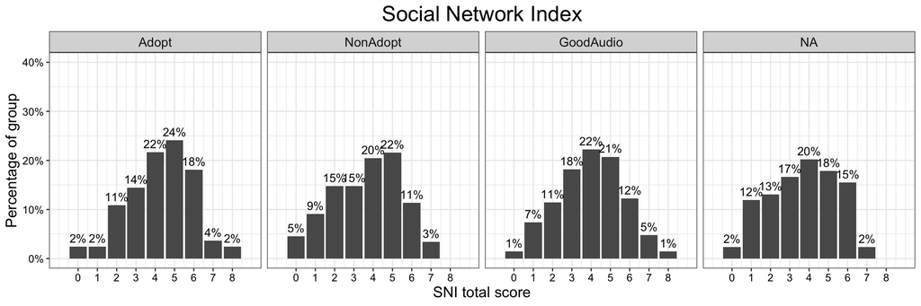

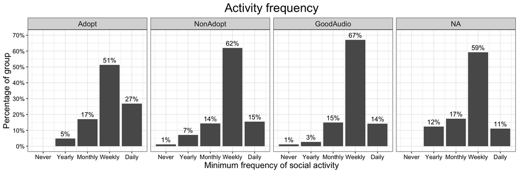

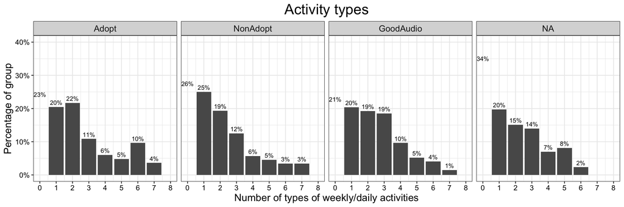

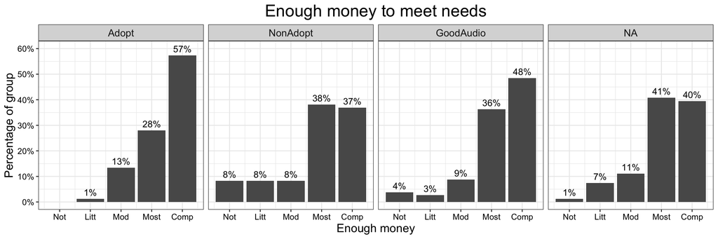

# Multinomial logistic regression

back to top

The reference group was NonAdopters (hearing aid candidates who did not acquire HA at any point).

Notes: 381 complete cases only (no missing data imputation), and no variable selection procedure yet.

Results:  
A model with these 18 variables explains 47% of the variance, when predicting who falls into the three groups. 80% of cases are correctly classified.  
Compared to NonAdopters, Adopters reported better speech understanding in noise.  
Compared to NonAdopters, the “Good Audiogram” group had better BPTA4 and less asymmetry, were less likely to live alone, but were more likely to report being lonely.

```
##                         Adopt(coef) Adopt(p) GdAud(coef) GdAud(p)
## (Intercept)                 -5.9537   0.0472     11.0215   0.0016
## PTA4_better_ear              0.0132   0.6132     -0.3259   0.0000
## PTA4_asym                   -0.0042   0.7287     -0.2523   0.0000
## SSQ15i_speech                0.3262   0.0032     -0.1001   0.4371
## vision_difficulty            0.9420   0.4652      2.1120   0.2443
## Age                         -0.0039   0.8908     -0.0119   0.7139
## Gender_rec                   0.2976   0.4483     -0.3039   0.5130
## Money_problem               -0.5340   0.3182      0.3340   0.6045
## Multimorbidity_score         0.0410   0.6691     -0.0655   0.5299
## CSRQ_mean                    0.7059   0.2082     -0.5825   0.3623
## Memory_worsening            -0.2846   0.4952      0.6233   0.1978
## Transport_problem            0.2793   0.7888     -0.3135   0.7792
## Retired                      0.1835   0.6727      0.9699   0.0582
## Lives_alone                 -0.6484   0.1820     -1.2847   0.0235
## Lonely                       1.0189   0.0791      1.7617   0.0069
## Soc_support                  0.4239   0.1188      0.3242   0.2799
## Social_network_index         0.0110   0.9442      0.1266   0.4872
## Soc_participation_freq       0.0001   0.9998     -0.2311   0.5205
## Soc_participation_types      0.1245   0.4105      0.1206   0.4957
```

```
##             Predicted
## Actual       NonAdopter Adopter Compare
##   NonAdopter         37      23      12
##   Adopter            13      52      15
##   Compare             4       9     216
```

# Logistic regression (Hamalainen et al. variables)

back to top

Comparing only Adopters and NonAdopters, 18 variables explain at most 15% of the variance in a model that predicts who adopts hearing aids. The top three variables are: the 15i-SSQ speech subscale, living alone, and social support.

Notes: List of variables resembles Hamalainen et al. (2021). 152 complete cases only, of a total of 171 Adopters and NonAdopters. No missing data imputation.

```
##
## Call:
## glm(formula = m2_formula, family = "binomial", data = compdata2gp)
##
## Coefficients:
##                           Estimate Std. Error z value Pr(>|z|)
## (Intercept)             -6.3431838  3.0620545  -2.072  0.03831 *
## PTA4_better_ear          0.0075449  0.0265538   0.284  0.77631
## PTA4_asym               -0.0060265  0.0120345  -0.501  0.61653
## SSQ15i_speech            0.3365890  0.1147177   2.934  0.00335 **
## vision_difficulty        0.9974157  1.3068031   0.763  0.44532
## Age                     -0.0003565  0.0286877  -0.012  0.99008
## Gender_rec               0.2677065  0.4111537   0.651  0.51498
## Money_problem           -0.6079413  0.5552039  -1.095  0.27352
## Multimorbidity_score     0.0174933  0.0991274   0.176  0.85992
## CSRQ_mean                0.7708973  0.5859040   1.316  0.18826
## Memory_worsening        -0.2112932  0.4170010  -0.507  0.61237
## Transport_problem        0.4346321  1.1327009   0.384  0.70119
## Retired                  0.2096667  0.4416401   0.475  0.63497
## Lives_alone             -0.7937799  0.5058506  -1.569  0.11660
## Lonely                   1.0643338  0.6091488   1.747  0.08059 .
## Soc_support              0.4895370  0.2787219   1.756  0.07903 .
## Social_network_index    -0.0073651  0.1631972  -0.045  0.96400
## Soc_participation_freq   0.0263926  0.3155639   0.084  0.93335
## Soc_participation_types  0.0976342  0.1514695   0.645  0.51920
## ---
## Signif. codes:  0 '***' 0.001 '**' 0.01 '*' 0.05 '.' 0.1 ' ' 1
##
## (Dispersion parameter for binomial family taken to be 1)
##
##     Null deviance: 210.30  on 151  degrees of freedom
## Residual deviance: 179.77  on 133  degrees of freedom
## AIC: 217.77
##
## Number of Fisher Scoring iterations: 4
```

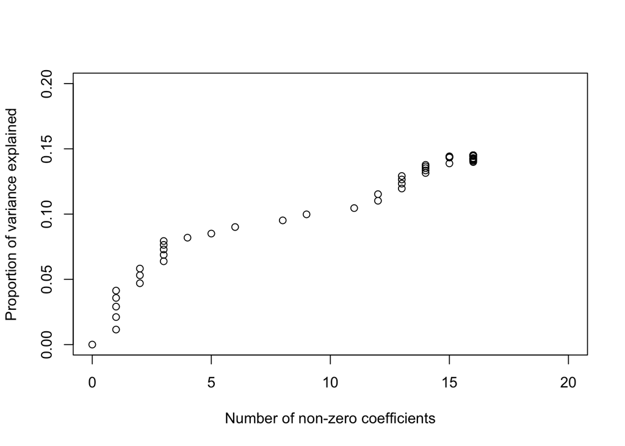

```
## 19 x 1 sparse Matrix of class "dgCMatrix"
##                                 s1
## (Intercept)             -1.4822616
## PTA4_better_ear          .
## PTA4_asym                .
## SSQ15i_speech            0.1791827
## vision_difficulty        .
## Age                      .
## Gender_rec               .
## Money_problem            .
## Multimorbidity_score     .
## CSRQ_mean                .
## Memory_worsening         .
## Transport_problem        .
## Retired                  .
## Lives_alone             -0.1579656
## Lonely                   .
## Soc_support              0.1159004
## Social_network_index     .
## Soc_participation_freq   .
## Soc_participation_types  .
```

# Logistic regression (our variables)

back to top

Comparing only Adopters and NonAdopters, 24 variables explain at 23% of the variance in a model that predicts who adopts hearing aids. The top 6 variables are: the three 15i-SSQ subscales, HHIE-S emotional subscale, WHO-BREF money question, and social support.

Notes: List of variables differs from Hamalainen et al. 140 complete cases only, of a total of 171 Adopters and NonAdopters. No missing data imputation.

```
##
## Call:
## glm(formula = m3_formula, family = "binomial", data = compdata2gp)
##
## Coefficients:
##                          Estimate Std. Error z value Pr(>|z|)
## (Intercept)             -7.688894   4.848070  -1.586  0.11275
## Age                     -0.019868   0.035799  -0.555  0.57890
## Gender_rec               1.019347   0.534932   1.906  0.05671 .
## Retired                  0.121208   0.525833   0.231  0.81770
## Phys_1_rate              0.403950   0.342807   1.178  0.23865
## Multimorbidity_score     0.069879   0.124015   0.563  0.57311
## PTA4_better_ear          0.008852   0.032052   0.276  0.78243
## PTA4_asym               -0.003753   0.014878  -0.252  0.80084
## SSQ15i_qualities         0.197765   0.197171   1.003  0.31585
## SSQ15i_spatial           0.028719   0.168778   0.170  0.86488
## SSQ15i_speech            0.287833   0.152886   1.883  0.05975 .
## SIM_mean                 0.239656   0.133647   1.793  0.07294 .
## Emocheq4_mean           -0.369258   0.343899  -1.074  0.28294
## HHIES_emo                0.115450   0.083036   1.390  0.16442
## HHIES_soc               -0.036544   0.085854  -0.426  0.67036
## Tinnitus_pastwk          0.056991   0.502662   0.113  0.90973
## ABC_mean                -0.030606   0.022495  -1.361  0.17366
## Memory_worsening        -0.065686   0.489819  -0.134  0.89332
## CSRQ_mean                0.120187   0.726393   0.165  0.86858
## WHO_money                0.754394   0.276797   2.725  0.00642 **
## Lonely                   1.632850   0.756152   2.159  0.03082 *
## Social_network_index     0.044775   0.183835   0.244  0.80757
## Soc_participation_freq  -0.248042   0.365438  -0.679  0.49729
## Soc_participation_types  0.197165   0.181287   1.088  0.27678
## Soc_support              0.393259   0.304942   1.290  0.19718
## ---
## Signif. codes:  0 '***' 0.001 '**' 0.01 '*' 0.05 '.' 0.1 ' ' 1
##
## (Dispersion parameter for binomial family taken to be 1)
##
##     Null deviance: 193.05  on 139  degrees of freedom
## Residual deviance: 148.49  on 115  degrees of freedom
## AIC: 198.49
##
## Number of Fisher Scoring iterations: 5
```

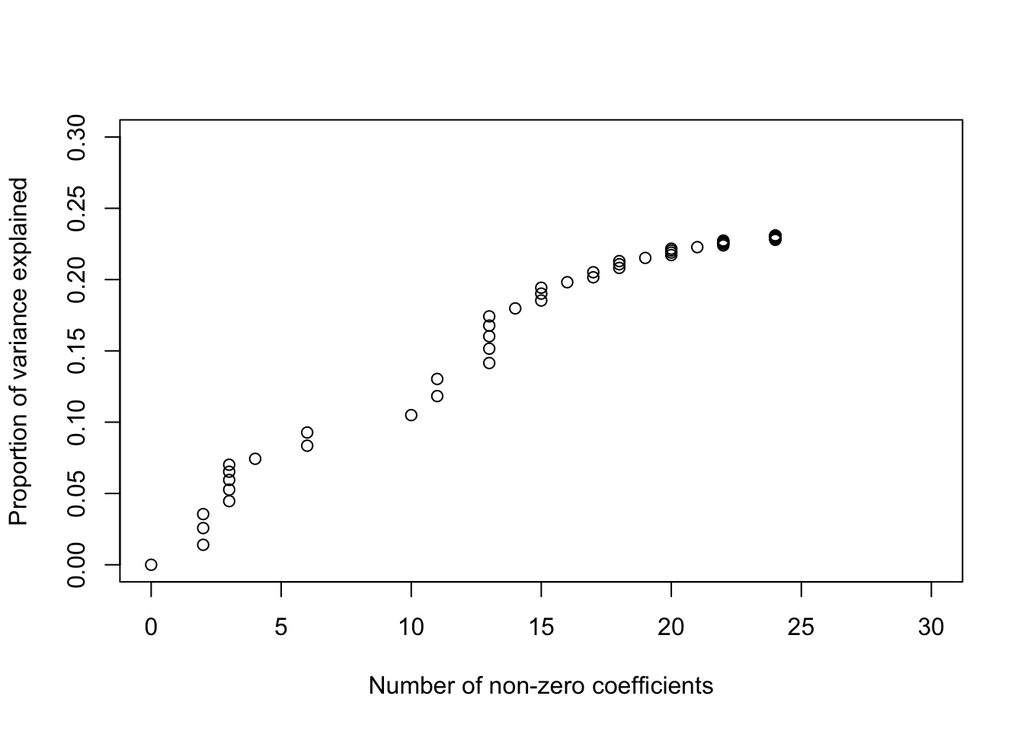

```
## 25 x 1 sparse Matrix of class "dgCMatrix"
##                                   s1
## (Intercept)             -1.891361639
## Age                      .
## Gender_rec               .
## Retired                  .
## Phys_1_rate              .
## Multimorbidity_score     .
## PTA4_better_ear          .
## PTA4_asym                .
## SSQ15i_qualities         0.063833286
## SSQ15i_spatial           0.001161011
## SSQ15i_speech            0.081151497
## SIM_mean                 .
## Emocheq4_mean            .
## HHIES_emo                0.000876758
## HHIES_soc                .
## Tinnitus_pastwk          .
## ABC_mean                 .
## Memory_worsening         .
## CSRQ_mean                .
## WHO_money                0.231489819
## Lonely                   .
## Social_network_index     .
## Soc_participation_freq   .
## Soc_participation_types  .
## Soc_support              0.001034798
```